# Example 3.2: Meuse data. Co-kriging prediction

Author

Aritz Adin and Tomás Goicoa

Published

Dec/2026

# 1 Objectives

In this example we will:

- Predict the concentration of **lead** (primary variable) in the Meuse study area using **zinc** (secondary variable), in the typical situation where the secondary variable has been observed at many more locations than the primary variable.
- Compare **ordinary kriging** (lead only) and **ordinary co-kriging** (lead and zinc) using prediction maps, their standard errors and cross-validation.

**TipR script**

You can download the R script with all the code of this example and follow it step by step in RStudio:

# 2 Packages

```r
library(dplyr)
library(gstat)
library(sf)
```

# 3 Description of the data

We use again the `meuse` dataset (see Example 3.1), together with the `meuse.grid` dataset, which contains the 3103 nodes of a regular grid (40 m × 40 m) covering the study area, where predictions will be computed.

```r
data(meuse, package="sp")         # soil samples
data(meuse.grid, package="sp")    # prediction grid

meuse_sf <- meuse |>
  as_tibble() |>
  st_as_sf(coords=c("x","y"), crs=28992)

grid_sf <- meuse.grid |>
  as_tibble() |>
  st_as_sf(coords=c("x","y"), crs=28992)
```

## Simulating the typical situation of co-kriging

In the Meuse data, lead and zinc have been measured at the same 155 locations. To reproduce the typical situation of co-kriging, we assume that lead has only been measured at a **random subset of 50 samples**, while zinc is available at all of them.

```r
set.seed(123)
idx <- sample(nrow(meuse_sf), 50)

lead_sf <- meuse_sf |> slice(idx)   # primary variable: 50 samples
zinc_sf <- meuse_sf                 # secondary variable: 155 samples
```

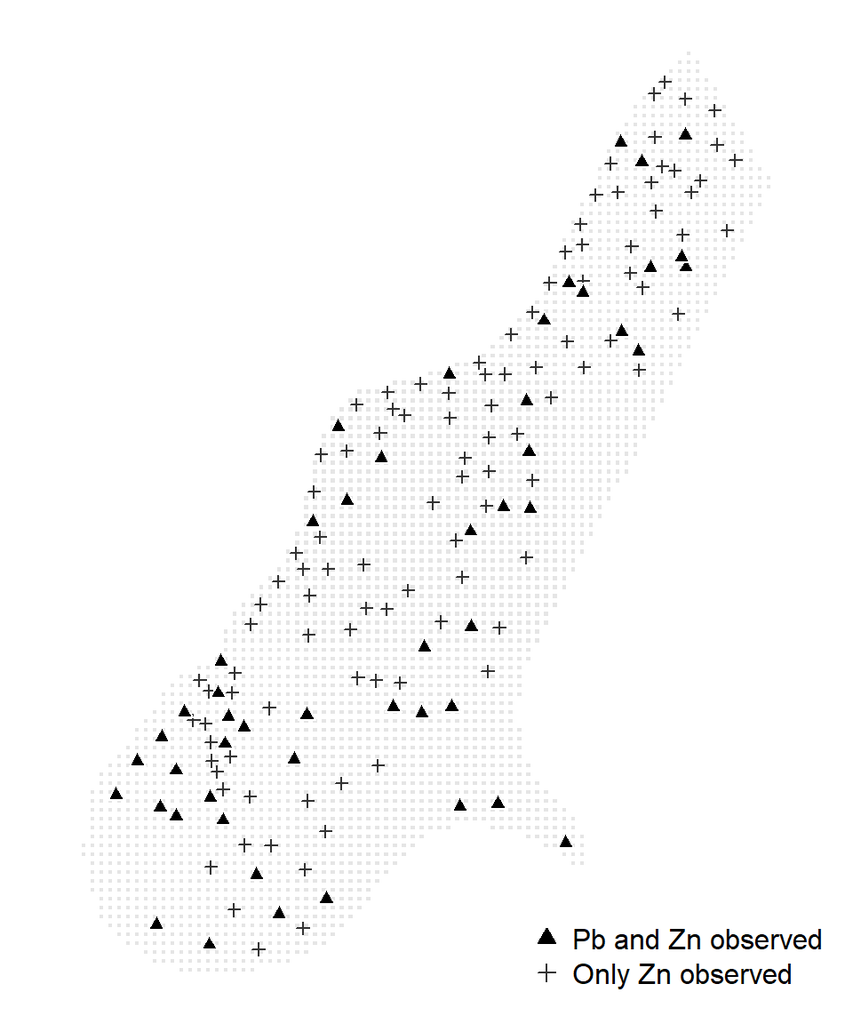

Sampling locations of lead and zinc.

# 4 Ordinary kriging (lead only)

First, we predict lead using only its own 50 observations, as in Chapter 2.

```r
v_lead <- variogram(log(lead) ~ 1, lead_sf)
vgm_lead <- fit.variogram(v_lead, model=vgm(psill=0.5, model="Sph",
                                            range=1000, nugget=0.05))
vgm_lead
```

```
  model     psill    range
1   Nug 0.1087297    0.000
2   Sph 0.4630695 1141.481
```

```r
pred_krig <- krige(log(lead) ~ 1, lead_sf, grid_sf, model=vgm_lead)
```

```
[using ordinary kriging]
```

```r
head(pred_krig)
```

```
Simple feature collection with 6 features and 2 fields
Geometry type: POINT
Dimension:     XY
Bounding box:  xmin: 181100 ymin: 333660 xmax: 181220 ymax: 333740
Projected CRS: Amersfoort / RD New
  var1.pred  var1.var              geometry
1  5.091976 0.4688758 POINT (181180 333740)
2  5.117656 0.4410914 POINT (181140 333700)
3  5.094199 0.4457431 POINT (181180 333700)
4  5.072002 0.4522404 POINT (181220 333700)
5  5.146331 0.4125887 POINT (181100 333660)
6  5.119523 0.4156324 POINT (181140 333660)
```

The function `krige()` returns, for each node of the grid:

| Column | Meaning | Notation |
| --- | --- | --- |
| `var1.pred` | Prediction (log scale) | $\hat{Z}_1(\mathbf{s}_0)$ |
| `var1.var` | Kriging variance (log scale) | $\sigma_K^2(\mathbf{s}_0)$ |

## 4.1 Direct and cross empirical semivariograms

As in Example 3.1, we create a `gstat` object with both variables. Note that now each variable has **its own data set**: lead is taken from `lead_sf` (50 samples) and zinc from `zinc_sf` (155 samples).

```r
g <- gstat(NULL, id = "Pb", formula = log(lead) ~ 1, data = lead_sf)
g <- gstat(g,    id = "Zn", formula = log(zinc) ~ 1, data = zinc_sf)

v <- variogram(g)
v |> filter(dist==0)
```

```
  np dist      gamma dir.hor dir.ver    id
1 50    0 0.01552923       0       0 Pb.Zn
```

**ImportantZero-distance lag in the cross-semivariogram**

The 50 lead samples are also zinc samples, so the cross-semivariogram includes pairs of observations at **distance 0** (lead and zinc measured at the same location). This creates an extra lag with `dist = 0`, which must be removed before fitting the model (otherwise, `fit.lmc()` returns an error).

```r
v <- v |> filter(dist>0)
```

## 4.2 Linear model of coregionalization

```r
lmc <- fit.lmc(v, g, model=vgm_lead)
lmc$model
```

```
$Pb
  model     psill    range
1   Nug 0.1087290    0.000
2   Sph 0.4861717 1141.481

$Pb.Zn
  model      psill    range
1   Nug 0.07708997    0.000
2   Sph 0.56026925 1141.481

$Zn
  model      psill    range
1   Nug 0.07787233    0.000
2   Sph 0.64566000 1141.481
```

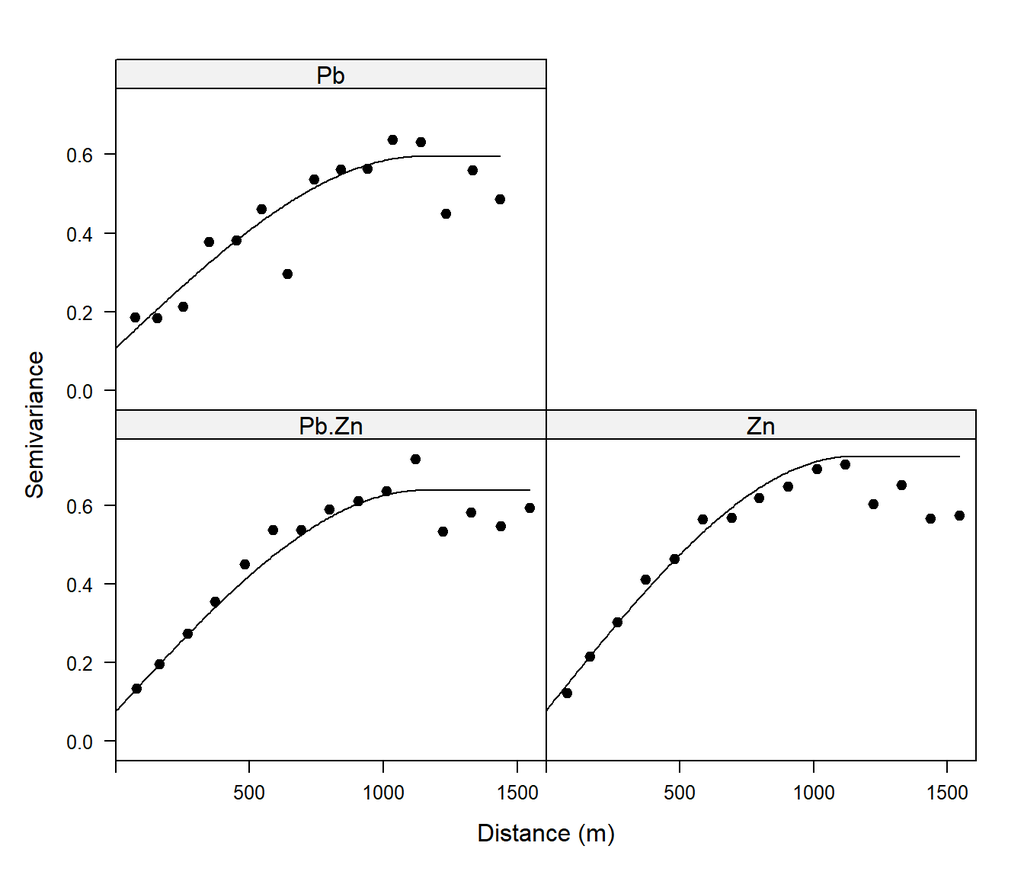

Direct and cross empirical semivariograms of log-lead (Pb, 50 samples) and log-zinc (Zn, 155 samples), with the fitted linear model of coregionalization.

```r
plot(v, lmc, pch = 19, col = "black",
     xlab = "Distance (m)", ylab = "Semivariance",
     scales = list(alternating = 1, tck = c(1, 0)))
```

## 4.3 Co-kriging predictions

The co-kriging predictions are computed with the function `predict()` applied to the fitted `gstat` object (unlike `krige()`, which is designed for a single variable):

```r
pred_cokrig <- predict(lmc, grid_sf)
```

```
Linear Model of Coregionalization found. Good.
[using ordinary cokriging]
```

```r
head(pred_cokrig)
```

```
Simple feature collection with 6 features and 5 fields
Geometry type: POINT
Dimension:     XY
Bounding box:  xmin: 181100 ymin: 333660 xmax: 181220 ymax: 333740
Projected CRS: Amersfoort / RD New
   Pb.pred    Pb.var  Zn.pred    Zn.var cov.Pb.Zn              geometry
1 5.437104 0.2971325 6.578509 0.3271530 0.2934217 POINT (181180 333740)
2 5.517853 0.2513901 6.671566 0.2664148 0.2407120 POINT (181140 333700)
3 5.425476 0.2646604 6.565109 0.2840377 0.2560045 POINT (181180 333700)
4 5.333357 0.2794909 6.458951 0.3037310 0.2730943 POINT (181220 333700)
5 5.610444 0.2030815 6.778268 0.2022671 0.1850444 POINT (181100 333660)
6 5.508475 0.2176514 6.660759 0.2216173 0.2018351 POINT (181140 333660)
```

For each node of the grid, it returns the predictions and variances of **both** variables, and the covariance between them:

| Column | Meaning | Notation |
| --- | --- | --- |
| `Pb.pred` | Prediction of lead (log scale) | $\hat{Z}_1(\mathbf{s}_0)$ |
| `Pb.var` | Co-kriging variance of lead (log scale) | $\sigma_{CK}^2(\mathbf{s}_0)$ |
| `Zn.pred`, `Zn.var` | Prediction and variance of zinc | — |
| `cov.Pb.Zn` | Covariance between both predictions | — |

We are interested in the columns of the primary variable (`Pb.pred` and `Pb.var`).

# 5 Comparison of the predictions

## Predictions

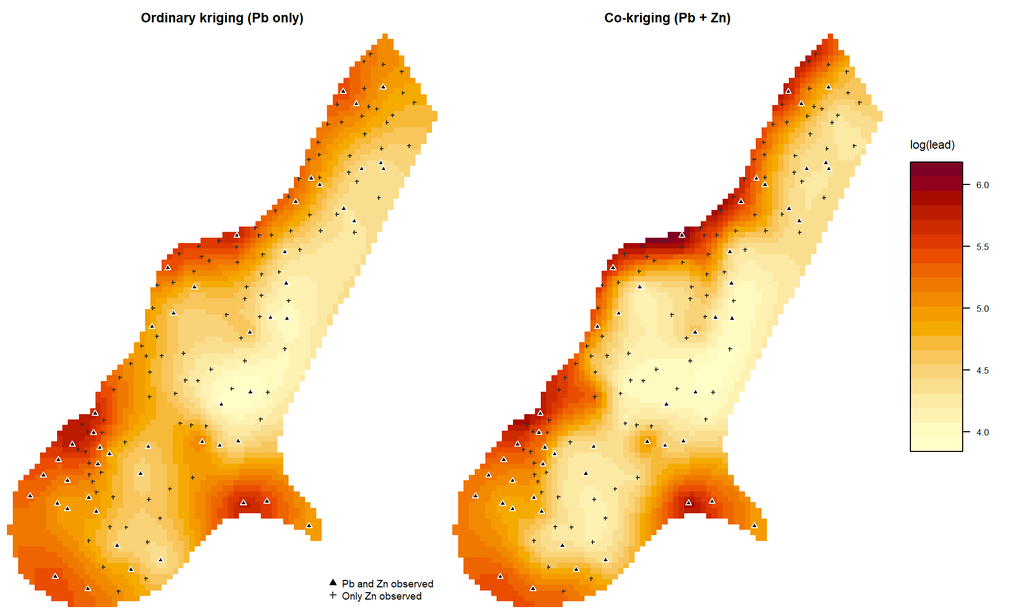

Predictions of lead (log scale) with ordinary kriging and co-kriging.

**NoteInterpretation**

Both maps show the same general pattern (higher concentrations near the river), but the co-kriging map is **more detailed**. In the areas without lead samples, ordinary kriging produces a smooth surface, while co-kriging uses the zinc samples to reproduce local variations. For example, the band of high concentrations along the river (in the north and centre of the study area) is much better captured by co-kriging.

**Note**

Predictions are shown on the log scale, the same scale as their standard errors. To obtain a final map of lead concentrations in ppm, predictions should be back-transformed with `exp()`.

## Standard errors

```r
pred_krig$se <- sqrt(pred_krig$var1.var)
pred_cokrig$se <- sqrt(pred_cokrig$Pb.var)
```

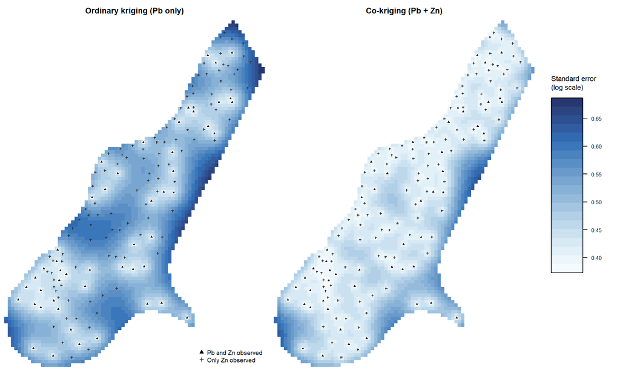

Standard errors of the predictions of lead (log scale) with ordinary kriging and co-kriging.

**NoteInterpretation**

- With ordinary kriging, the standard error is small only near the lead samples (triangles) and increases in the areas where only zinc has been observed (crosses).
- With co-kriging, the standard error is reduced over almost the whole study area, also near the zinc samples. The median standard error decreases from 0.52 to 0.43.

# 6 Cross-validation

The reduction of the standard errors is what the fitted model predicts. To check whether co-kriging actually reduces the prediction errors, we compare both methods using leave-one-out cross-validation (Chapter 2) on the 50 lead samples.

```r
# Ordinary kriging
cv_krig <- krige.cv(log(lead) ~ 1, lead_sf, model=vgm_lead, nfold=nrow(lead_sf))

# Co-kriging
cv_cokrig <- gstat.cv(lmc, nfold=nrow(lead_sf), remove.all=TRUE, debug.level=0)
```

**ImportantThe argument `remove.all = TRUE`**

By default, `gstat.cv()` only removes the observation of the primary variable at each location, and keeps the zinc observation measured at the **same location**. Since lead and zinc are very highly correlated, this would give over-optimistic results, because the nodes of the prediction grid have no zinc observations. With `remove.all = TRUE`, the observations of **both** variables at that location are removed.

Both functions return the cross-validation errors in the column `residual` (observed minus predicted value):

```r
cv_results <- data.frame(
  Method = c("Ordinary kriging", "Co-kriging"),
  MAE    = c(mean(abs(cv_krig$residual)), mean(abs(cv_cokrig$residual))),
  RMSE   = c(sqrt(mean(cv_krig$residual^2)), sqrt(mean(cv_cokrig$residual^2)))
)
cv_results |>
  mutate(MAE = round(MAE, 3),
         RMSE=round(RMSE, 3))
```

```
            Method   MAE  RMSE
1 Ordinary kriging 0.450 0.560
2       Co-kriging 0.316 0.436
```

**NoteInterpretation**

Co-kriging reduces both cross-validation errors: the RMSE decreases from 0.560 to 0.436 (a reduction of about 22%). Therefore, in this situation (few lead samples and many zinc samples strongly correlated in space), using zinc as a secondary variable clearly improves the prediction of lead.

# 7 Summary of the workflow

| Step | Function | Result |
| --- | --- | --- |
| Ordinary kriging of the primary variable | `variogram()` + `fit.variogram()` + `krige()` | Predictions and kriging variances |
| Direct and cross empirical semivariograms | `gstat()` + `variogram()` | Points of the three semivariograms |
| Linear model of coregionalization | `fit.lmc()` | Fitted `gstat` object |
| Co-kriging predictions | `predict()` | Predictions and co-kriging variances |
| Comparison of both methods | `krige.cv()` and `gstat.cv(..., remove.all = TRUE)` | MAE and RMSE |

# 8 Exercise

In the Meuse data, lead and zinc have actually been measured at the same 155 locations (co-located samples). Repeat the comparison between ordinary kriging and co-kriging using **all the lead observations**.

Answer the following questions:

- Does co-kriging still reduce the cross-validation errors?
- Why?

## Solution

Cross-validation errors with lead observed at all 155 locations:

```
            Method   MAE  RMSE
1 Ordinary kriging 0.295 0.402
2       Co-kriging 0.293 0.399
```

**Interpretation:**

- When lead has been observed at all 155 locations, co-kriging **hardly improves** on ordinary kriging: the RMSE is 0.402 with ordinary kriging and 0.399 with co-kriging, whereas in the example (lead observed at only 50 locations) co-kriging reduced the RMSE by about 22%.
- The reason is that zinc does not provide new spatial information: at every location where zinc is available, lead is also available. Co-kriging is most useful when the secondary variable has been observed at **many more locations** than the primary variable, as in the example.